# Problem Statement

## Feature Selection

This is the process of selecting features which are most relevant in predicting the output variable.

- $\implies$ It helps reduce data dimensionaluty and
- $\implies$ Ensures that models' accuracy can be trusted when those features are out. Learn more [here](https://en.wikipedia.org/wiki/Feature_selection).

After looking at both numerical and categorical variables, we can be certain about how some of those features affect car pricing. We saw that the following numerical features have medium to storng correlations with price:

### *Variance Threshold*

```python
#df[['wheelbase', 'carlength', 'carwidth', 'curbweight','enginesize', 'boreratio', 'horsepower', 'citympg', 'highwaympg', 'price']].corr().T

#df_cardims_corr
strong_corr = df_num.corr().round(5)

# Correlation of features vs price only
# Set thrashhold: anything greater or equal to 0.65 is good
num_threshold = 0.5
f = abs(strong_corr['price'])
output_f = pd.DataFrame(f[f>num_threshold])
output_f
```

|  | price |
| --- | --- |
| wheelbase | 0.57782 |
| carlength | 0.68292 |
| carwidth | 0.75933 |
| curbweight | 0.83530 |
| enginesize | 0.87414 |
| boreratio | 0.55317 |
| horsepower | 0.80814 |
| citympg | 0.68575 |
| highwaympg | 0.69760 |
| price | 1.00000 |
| fueleconomy | 0.69621 |

```python
df.head(5)
```

|  | car_ID | symboling | CarName | fueltype | aspiration | doornumber | carbody | drivewheel | enginelocation | wheelbase | carlength | carwidth | carheight | curbweight | enginetype | cylindernumber | enginesize | fuelsystem | boreratio | stroke | compressionratio | horsepower | peakrpm | citympg | highwaympg | price |
| --- | --- | --- | --- | --- | --- | --- | --- | --- | --- | --- | --- | --- | --- | --- | --- | --- | --- | --- | --- | --- | --- | --- | --- | --- | --- | --- |
| 0 | 1 | 3 | alfa-romero | gas | std | two | convertible | rwd | front | 88.6 | 168.8 | 64.1 | 48.8 | 2548 | dohc | four | 130 | mpfi | 3.47 | 2.68 | 9.0 | 111 | 5000 | 21 | 27 | 13495.0 |
| 1 | 2 | 3 | alfa-romero | gas | std | two | convertible | rwd | front | 88.6 | 168.8 | 64.1 | 48.8 | 2548 | dohc | four | 130 | mpfi | 3.47 | 2.68 | 9.0 | 111 | 5000 | 21 | 27 | 16500.0 |
| 2 | 3 | 1 | alfa-romero | gas | std | two | hatchback | rwd | front | 94.5 | 171.2 | 65.5 | 52.4 | 2823 | ohcv | six | 152 | mpfi | 2.68 | 3.47 | 9.0 | 154 | 5000 | 19 | 26 | 16500.0 |
| 3 | 4 | 2 | audi | gas | std | four | sedan | fwd | front | 99.8 | 176.6 | 66.2 | 54.3 | 2337 | ohc | four | 109 | mpfi | 3.19 | 3.40 | 10.0 | 102 | 5500 | 24 | 30 | 13950.0 |
| 4 | 5 | 2 | audi | gas | std | four | sedan | 4wd | front | 99.4 | 176.6 | 66.4 | 54.3 | 2824 | ohc | five | 136 | mpfi | 3.19 | 3.40 | 8.0 | 115 | 5500 | 18 | 22 | 17450.0 |

#### $Observation$

We see the above numerical features can be used in predicting the target.

We can safely say that the following features play the biggest part in predicting car prices:

# Data Modeling

Taking into account the above, let's have them grouped into one dataframe.

```python
auto = car_data[['wheelbase', 'carlength', 'carwidth', 'curbweight',
                 'enginesize', 'boreratio', 'horsepower', 'aspiration',
                 'carbody', 'enginetype', 'drivewheel', 'cylindernumber',
                 'fueltype', 'fueleconomy', 'price',]]
```

```python
auto.head()
```

|  | wheelbase | carlength | carwidth | curbweight | enginesize | boreratio | horsepower | aspiration | carbody | enginetype | drivewheel | cylindernumber | fueltype | fueleconomy | price |
| --- | --- | --- | --- | --- | --- | --- | --- | --- | --- | --- | --- | --- | --- | --- | --- |
| 0 | 88.6 | 168.8 | 64.1 | 2548 | 130 | 3.47 | 111 | 0 | 0 | 0 | 2 | 2 | 1 | 23.70 | 13495.0 |
| 1 | 88.6 | 168.8 | 64.1 | 2548 | 130 | 3.47 | 111 | 0 | 0 | 0 | 2 | 2 | 1 | 23.70 | 16500.0 |
| 2 | 94.5 | 171.2 | 65.5 | 2823 | 152 | 2.68 | 154 | 0 | 2 | 5 | 2 | 3 | 1 | 22.15 | 16500.0 |
| 3 | 99.8 | 176.6 | 66.2 | 2337 | 109 | 3.19 | 102 | 0 | 3 | 3 | 1 | 2 | 1 | 26.70 | 13950.0 |
| 4 | 99.4 | 176.6 | 66.4 | 2824 | 136 | 3.19 | 115 | 0 | 3 | 3 | 0 | 1 | 1 | 19.80 | 17450.0 |

### Splitting the Data into Training and Testing sets

```python
# Split into target variable and independent variables
X = auto.drop(['price'], axis = 1)

# target
y = auto['price']
```

```python
from sklearn.model_selection import train_test_split
X_train, X_test, y_train, y_test = train_test_split(X, y, test_size = 0.3, random_state=0)
```

Let's check the sizes of the training and testing sets.

```python
#print('-'*48)
print('X_train has', X_train.shape[0], 'rows, y_train also has', y_train.shape[0], 'rows')
print('-'*48)
print('X_test has', X_test.shape[0], 'rows, y_test also has', y_test.shape[0], 'rows')
print('-'*48)
print('X_train has', X_train.shape[1], 'features; X_test also has', X_test.shape[1], 'rows')
```

```
X_train has 143 rows, y_train also has 143 rows
------------------------------------------------
X_test has 62 rows, y_test also has 62 rows
------------------------------------------------
X_train has 14 features; X_test also has 14 rows
```

So train sets match, with $143$ entries, and *`X_train`* and *`X_test`* also match, with $14$ rows.

# Data Modeling

## Linear Regression Model

> - Assign `LinearRegresson` to the variable **"lin_reg-mod"**
> - Then we fit the *$X$_$train$* and *$y$_$train$* data to the model using `lin_reg_mod.fit()` function.

```python
# Create a linear regressor
lin_reg_mod = LinearRegression()

# Train the model using the X_train  and y_train sets
lin_reg_mod.fit(X_train, y_train)
```

```
LinearRegression(copy_X=True, fit_intercept=True, n_jobs=None, normalize=False)
```

### 2. Model Prediction on Test Data

> - Here we predict the results of the test set
> - We use `lin_reg_mod.predict()` function and assign it to the variable "*lin_reg_y_test_pred*".

```python
# Model prediction on test data
lin_reg_y_test_pred = lin_reg_mod.predict(X_test)
#y_pred_train = lin_reg_mod.predict(X_train)b
```

### 3. Model Evaluation

- **R-Square** - $R^2$

```python
# Evaluation Metrics
# RSquare
from sklearn.metrics import r2_score

# Print RSquare Score for train data
#print("Train data R-squared score: {}".format(r2_score(y_true = y_train, y_pred = y_pred_train)))

# Print RSquare Score for test data
print("Test data R-squared score for Linear Regression Model is {}".format(r2_score(y_test, lin_reg_y_test_pred)))
```

```
Test data R-squared score for Linear Regression Model is 0.7709910730089351
```

## Decision Tree Regressor

### 1. Training the Decision Tree Regression Model

> - Assign `DecisionTreeRegressor` to the variable **"dt_regressor"**
> - Then we fit the *$X$_$train$* and *$y$_$train$* data to the model using `dt_regressor.fit()` function.

```python
# Assign DecisionTreeRegressor to the variable "dt_regressor"
dt_regressor = DecisionTreeRegressor(random_state=0)
# Fit the training data to the model
dt_regressor.fit(X_train, y_train)
```

```
DecisionTreeRegressor(ccp_alpha=0.0, criterion='mse', max_depth=None,
                      max_features=None, max_leaf_nodes=None,
                      min_impurity_decrease=0.0, min_impurity_split=None,
                      min_samples_leaf=1, min_samples_split=2,
                      min_weight_fraction_leaf=0.0, presort='deprecated',
                      random_state=0, splitter='best')
```

### 2. Model Prediction: Predicting the Results

> - Here we predict the results of the test set with which the model trained on the training set values;
> - We use `dt_regressor.predict()` function and assign it to the variable "*dtr_y_test_pred*".

```python
#dt_y_train_pred = dt_regressor.predict(X_train)
# Predict the results
dt_y_test_pred = dt_regressor.predict(X_test)
```

### 3. Model Evaluation

```python
# Evaluate the Model
dt_regressor.score(X_test, y_test)
# Evaluate the model
print("Test dataset df_regressor score for Decision Tree Regression Model is {}".format(dt_regressor.score(X_test, y_test)))
```

```
Test dataset df_regressor score for Decision Tree Regression Model is 0.8703338068123568
```

## Random Forest Regressor

> - Assign `RandomForestRegressor` to the variable **"rf_regressor"**
> - Then we fit the *$X$_$train$* and *$y$_$train$* data to the model using `rf_regressor.fit()` function.

```python
# Assign the RandomForestRegressor to rf
rf_regressor = RandomForestRegressor(n_estimators = 100,
                           criterion = 'mse',
                           random_state = 0,
                           n_jobs = -1)
# Fit the Model with training data
rf_regressor.fit(X_train, y_train)
```

```
RandomForestRegressor(bootstrap=True, ccp_alpha=0.0, criterion='mse',
                      max_depth=None, max_features='auto', max_leaf_nodes=None,
                      max_samples=None, min_impurity_decrease=0.0,
                      min_impurity_split=None, min_samples_leaf=1,
                      min_samples_split=2, min_weight_fraction_leaf=0.0,
                      n_estimators=100, n_jobs=-1, oob_score=False,
                      random_state=0, verbose=0, warm_start=False)
```

### 2. Model Prediction: Predicting the Results

> - Here we predict the results of the test set with which the model trained on the training set values;
> - We use `regressor.predict()` function and assign it to the variable "*rf_y_test_pred*".

```python
# Model Prediction
#rf_train_pred = rfr.predict(X_train)
rf_y_test_pred = rf_regressor.predict(X_test)
```

### 3. Model Evaluation

```python
# Evaluate the model
print("Test dataset R-squared score for Random Forest Regressor Model is {}".format(rf_regressor.score(X_test, y_test)))
```

```
Test dataset R-squared score for Random Forest Regressor Model is 0.9081702066501544
```

```python
print("Linear Regression RSquared score is {}".format(r2_score(y_test, lin_reg_y_test_pred)))
print("Decision Tree Regression Score is   {}".format(dt_regressor.score(X_test, y_test)))
print("Random Forest Regressor Score is    {}".format(rf_regressor.score(X_test, y_test)))
```

```
Linear Regression RSquared score is 0.7709910730089351
Decision Tree Regression Score is   0.8703338068123568
Random Forest Regressor Score is    0.9081702066501544
```

### Comparing Real $vs.$ Predicted Values

- Let's display the values of *y_test* as **"Real Values"** and *lin_reg_y_test_pred* as **"Predicted Values"** in a Pandas DataFrame.

```python
lr_df = pd.DataFrame({'Real Values': y_test, 'Predicted Values': lin_reg_y_test_pred})
dt_df = pd.DataFrame({'Real Values': y_test, 'Predicted Values': dt_y_test_pred})
rf_df = pd.DataFrame({'Real Values': y_test, 'Predicted Values': rf_y_test_pred})
```

### Visualizing Models Results

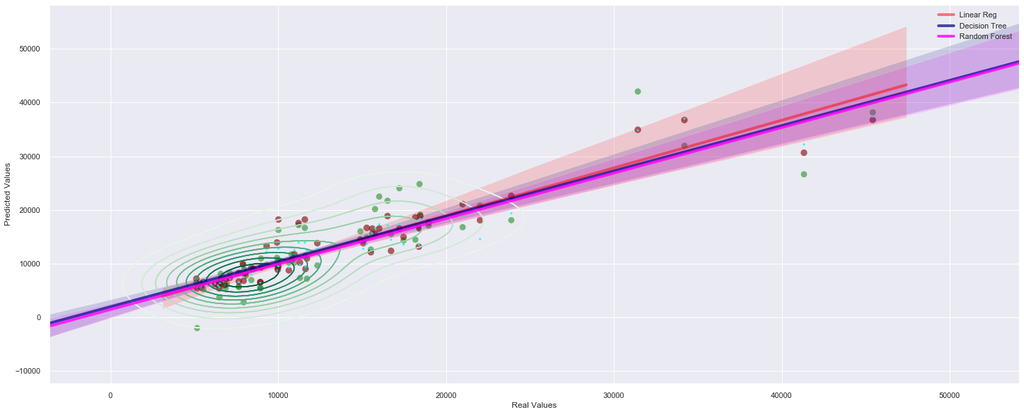

```python
fig = plt.figure(figsize=(25, 10))
#plt.subplot(2, 2, 1)
# Regression Scatter Plot for Compression Ratio
sns.regplot(x=lr_df['Real Values'], y=lr_df['Predicted Values'], data=lr_df,
            scatter_kws = {'color': 'green', 'alpha':0.5,"s":80, "cmap":"plasma", 'marker':'+'},
            line_kws = {'color': 'red', 'alpha':0.5, 'lw':4, 'label':'Linear Reg'})
sns.kdeplot(lr_df['Real Values'], lr_df['Predicted Values'], cmap="Blues")
plt.legend()
sns.regplot(x=dt_df['Real Values'], y=dt_df['Predicted Values'], data=dt_df,
            scatter_kws = {'color': 'maroon', 'alpha':0.6,"s":90, "cmap":"Blues", 'marker':'+'},
            line_kws = {'color': 'darkblue', 'alpha':0.7, 'lw':4, 'label':'Decision Tree'})
sns.kdeplot(lr_df['Real Values'], lr_df['Predicted Values'], cmap="Blues")
plt.legend()
sns.regplot(x=rf_df['Real Values'], y=rf_df['Predicted Values'], data=rf_df,
            scatter_kws = {'color': 'cyan', 'alpha':0.8,"s":10, "cmap":"Blues", 'marker':'+'},
            line_kws = {'color': 'magenta', 'alpha':0.8, 'lw':4, 'label':'Random Forest'})
sns.kdeplot(lr_df['Real Values'], lr_df['Predicted Values'], cmap="Greens", shade=False)
plt.legend()

#plt.subplot(2, 2, 2)
#plt.bar(lin_reg, lin_reg.values())
```

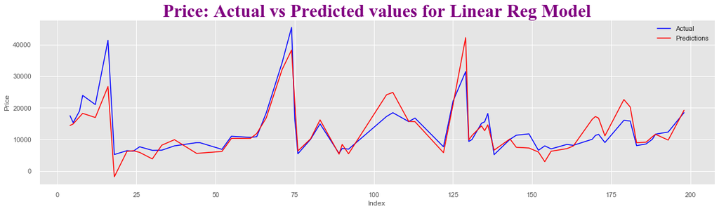

```python
plt.style.use('ggplot')
fig, ax = plt.subplots(figsize=(20, 5))
# Linear Reg Model Predictions
sns.lineplot(x = y_test.index, y = y_test, label = "Actual", color = "blue", ax = ax)
sns.lineplot(x = y_test.index, y = lin_reg_y_test_pred, label = "Predictions", color = "red", ax = ax)
ax.set_title("Price: Actual vs Predicted values for Linear Reg Model", fontname ='Times New Roman', size = 30, color ='purple')
ax.set_xlabel("Index")
ax.set_ylabel("Price")
```

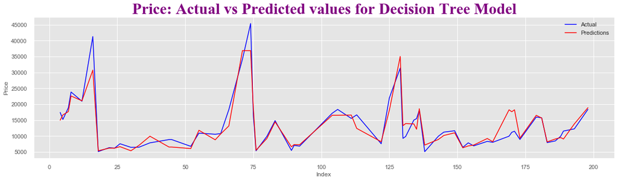

```python
plt.style.use('ggplot')
fig, ax = plt.subplots(figsize=(20, 5))
#
sns.lineplot(x = y_test.index, y = y_test, label = "Actual", color = "blue", ax = ax)
sns.lineplot(x = y_test.index, y = dt_y_test_pred, label = "Predictions", color = "red", ax = ax)
ax.set_title("Price: Actual vs Predicted values for Decision Tree Model", fontname ='Times New Roman', size = 30, color ='purple')
ax.set_xlabel("Index")
ax.set_ylabel("Price")
```

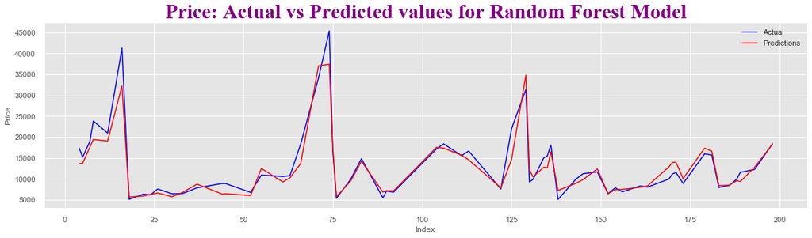

```python
plt.style.use('ggplot')
fig, ax = plt.subplots(figsize=(20, 5))

sns.lineplot(x = y_test.index, y = y_test, label = "Actual", color = "blue", ax = ax)
sns.lineplot(x = y_test.index, y = rf_y_test_pred, label = "Predictions", color = "red", ax = ax)
ax.set_title("Price: Actual vs Predicted values for Random Forest Model", fontname ='Times New Roman', size = 30, color ='purple')
ax.set_xlabel("Index")
ax.set_ylabel("Price")
```

# Conclusion

- After using 3 different models- Linear Regression Model, Decision Tree Regression Model and Random Forest Regression Model, we see that Random Forest Regressor scored about 90.82%, which would be the model of choice for this project.